# Regression Model for Ames Iowa Housing Prices Using R Take 3

David Lowe

July 5, 2019

Template Credit: Adapted from a template made available by Dr. Jason Brownlee of Machine Learning Mastery. [http://machinelearningmastery.com/]

SUMMARY: The purpose of this project is to construct a prediction model using various machine learning algorithms and to document the end-to-end steps using a template. The Ames Iowa Housing Prices dataset is a regression situation where we are trying to predict the value of a continuous variable.

INTRODUCTION: Many factors can influence a home’s purchase price. This Ames Housing dataset contains 79 explanatory variables describing every aspect of residential homes in Ames, Iowa. The goal is to predict the final price of each home.

In iteration Take1, we established the baseline mean squared error for further takes of modeling.

In iteration Take2, we converted some of the categorical variables from nominal to ordinal and observed the effects of the change.

In this iteration, we will examine the feature selection technique of attribute importance ranking by using the Lasso algorithm. By selecting only the most important attributes, we hope to decrease the processing time and maintain a similar level of RMSE compared to the baseline.

ANALYSIS: The baseline performance of the machine learning algorithms achieved an average RMSE of 32,826. Two algorithms (Elasticnet and Gradient Boosting) achieved the top RMSE metrics after the first round of modeling. After a series of tuning trials, Gradient Boosting turned in the best overall result and achieved an RMSE metric of 23,246. By using the optimized parameters, the Gradient Boosting algorithm processed the test dataset with an RMSE of 23,859, which was slightly higher than the prediction from the training data.

From iteration Take2, Gradient Boosting achieved an RMSE metric of 23,466 with the training dataset and processed the test dataset with an RMSE of 23,118. Converting the nominal variables into ordinal did not have a material impact on the prediction accuracy in either direction.

From iteration Take3, Gradient Boosting achieved an RMSE metric of 24,132 with the training dataset and processed the test dataset with an RMSE of 23,918. At the importance level of 99%, the attribute importance technique eliminated 20 of 64 total attributes. The remaining 44 attributes produced a model that achieved a comparable RMSE to the baseline model.

CONCLUSION: For this iteration, the Gradient Boosting algorithm achieved the best overall results using the training and testing datasets. For this dataset, Gradient Boosting should be considered for further modeling.

Dataset Used: Kaggle Competition - House Prices: Advanced Regression Techniques

Dataset ML Model: Regression with numerical and categorical attributes

Dataset Reference: https://ww2.amstat.org/publications/jse/v19n3/decock.pdf

One potential source of performance benchmark: https://www.kaggle.com/c/house-prices-advanced-regression-techniques

The project aims to touch on the following areas:

1. Document a predictive modeling problem end-to-end.
2. Explore data cleaning and transformation options
3. Explore non-ensemble and ensemble algorithms for baseline model performance
4. Explore algorithm tuning techniques for improving model performance

Any predictive modeling machine learning project genrally can be broken down into about six major tasks:

1. Prepare Problem
2. Summarize Data
3. Prepare Data
4. Model and Evaluate Algorithms
5. Improve Accuracy or Results
6. Finalize Model and Present Results

## 1. Prepare Problem

### 1.a) Load libraries

```r
startTimeScript <- proc.time()
library(caret)
```

```r
library(corrplot)
library(DMwR)
library(Hmisc)
library(mailR)
library(ROCR)
library(stringr)
```

```r
# Create one random seed number for reproducible results
seedNum <- 888
set.seed(seedNum)

# Set up the flag to send status emails (setting TRUE will send!)
notifyStatus <- FALSE
```

### 1.b) Set up the email notification function

```r
email_notify <- function(msg=""){
  sender <- Sys.getenv("MAIL_SENDER")
  receiver <- Sys.getenv("MAIL_RECEIVER")
  gateway <- Sys.getenv("SMTP_GATEWAY")
  smtpuser <- Sys.getenv("SMTP_USERNAME")
  password <- Sys.getenv("SMTP_PASSWORD")
  sbj_line <- "Notification from R Binary Classification Script"
  send.mail(
    from = sender,
    to = receiver,
    subject= sbj_line,
    body = msg,
    smtp = list(host.name = gateway, port = 587, user.name = smtpuser, passwd = password, ssl = TRUE),
    authenticate = TRUE,
    send = TRUE)
}
```

```r
if (notifyStatus) email_notify(paste("Library and Data Loading has begun!",date()))
```

### 1.c) Load dataset

```r
# Slicing up the document path to get the final destination file name
dataset_path <- 'https://www.kaggle.com/c/house-prices-advanced-regression-techniques/download/train.csv'
doc_path_list <- str_split(dataset_path, "/")
dest_file <- doc_path_list[[1]][length(doc_path_list[[1]])]

if (!file.exists(dest_file)) {
  # Download the document from the website
  cat("Downloading", dataset_path, "as", dest_file, "\n")
  download.file(dataset_path, dest_file, mode = "wb")
  cat(dest_file, "downloaded!\n")
#  unzip(dest_file)
#  cat(dest_file, "unpacked!\n")
}

inputFile <- dest_file
xy_original <- read.csv(inputFile, header = TRUE, sep = ",", row.names = 1, stringsAsFactors = FALSE)
```

```r
# Take a peek at the dataframe after the import
head(xy_original)
```

```
##   MSSubClass MSZoning LotFrontage LotArea Street Alley LotShape
## 1         60       RL          65    8450   Pave  <NA>      Reg
## 2         20       RL          80    9600   Pave  <NA>      Reg
## 3         60       RL          68   11250   Pave  <NA>      IR1
## 4         70       RL          60    9550   Pave  <NA>      IR1
## 5         60       RL          84   14260   Pave  <NA>      IR1
## 6         50       RL          85   14115   Pave  <NA>      IR1
##   LandContour Utilities LotConfig LandSlope Neighborhood Condition1
## 1         Lvl    AllPub    Inside       Gtl      CollgCr       Norm
## 2         Lvl    AllPub       FR2       Gtl      Veenker      Feedr
## 3         Lvl    AllPub    Inside       Gtl      CollgCr       Norm
## 4         Lvl    AllPub    Corner       Gtl      Crawfor       Norm
## 5         Lvl    AllPub       FR2       Gtl      NoRidge       Norm
## 6         Lvl    AllPub    Inside       Gtl      Mitchel       Norm
##   Condition2 BldgType HouseStyle OverallQual OverallCond YearBuilt
```

[output cut: 76 more lines]

```r
sapply(xy_original, class)
```

```
##    MSSubClass      MSZoning   LotFrontage       LotArea        Street
##     "integer"   "character"     "integer"     "integer"   "character"
##         Alley      LotShape   LandContour     Utilities     LotConfig
##   "character"   "character"   "character"   "character"   "character"
##     LandSlope  Neighborhood    Condition1    Condition2      BldgType
##   "character"   "character"   "character"   "character"   "character"
##    HouseStyle   OverallQual   OverallCond     YearBuilt  YearRemodAdd
##   "character"     "integer"     "integer"     "integer"     "integer"
##     RoofStyle      RoofMatl   Exterior1st   Exterior2nd    MasVnrType
##   "character"   "character"   "character"   "character"   "character"
##    MasVnrArea     ExterQual     ExterCond    Foundation      BsmtQual
##     "integer"   "character"   "character"   "character"   "character"
##      BsmtCond  BsmtExposure  BsmtFinType1    BsmtFinSF1  BsmtFinType2
##   "character"   "character"   "character"     "integer"   "character"
##    BsmtFinSF2     BsmtUnfSF   TotalBsmtSF       Heating     HeatingQC
##     "integer"     "integer"     "integer"   "character"   "character"
##    CentralAir    Electrical     X1stFlrSF     X2ndFlrSF  LowQualFinSF
##   "character"   "character"     "integer"     "integer"     "integer"
##     GrLivArea  BsmtFullBath  BsmtHalfBath      FullBath      HalfBath
##     "integer"     "integer"     "integer"     "integer"     "integer"
##  BedroomAbvGr  KitchenAbvGr   KitchenQual  TotRmsAbvGrd    Functional
##     "integer"     "integer"   "character"     "integer"   "character"
##    Fireplaces   FireplaceQu    GarageType   GarageYrBlt  GarageFinish
##     "integer"   "character"   "character"     "integer"   "character"
##    GarageCars    GarageArea    GarageQual    GarageCond    PavedDrive
##     "integer"     "integer"   "character"   "character"   "character"
##    WoodDeckSF   OpenPorchSF EnclosedPorch    X3SsnPorch   ScreenPorch
##     "integer"     "integer"     "integer"     "integer"     "integer"
##      PoolArea        PoolQC         Fence   MiscFeature       MiscVal
##     "integer"   "character"   "character"   "character"     "integer"
##        MoSold        YrSold      SaleType SaleCondition     SalePrice
##     "integer"     "integer"   "character"   "character"     "integer"
```

```r
sapply(xy_original, function(x) sum(is.na(x)))
```

```
##    MSSubClass      MSZoning   LotFrontage       LotArea        Street
##             0             0           259             0             0
##         Alley      LotShape   LandContour     Utilities     LotConfig
##          1369             0             0             0             0
##     LandSlope  Neighborhood    Condition1    Condition2      BldgType
##             0             0             0             0             0
##    HouseStyle   OverallQual   OverallCond     YearBuilt  YearRemodAdd
##             0             0             0             0             0
##     RoofStyle      RoofMatl   Exterior1st   Exterior2nd    MasVnrType
##             0             0             0             0             8
##    MasVnrArea     ExterQual     ExterCond    Foundation      BsmtQual
##             8             0             0             0            37
##      BsmtCond  BsmtExposure  BsmtFinType1    BsmtFinSF1  BsmtFinType2
##            37            38            37             0            38
##    BsmtFinSF2     BsmtUnfSF   TotalBsmtSF       Heating     HeatingQC
##             0             0             0             0             0
##    CentralAir    Electrical     X1stFlrSF     X2ndFlrSF  LowQualFinSF
##             0             1             0             0             0
##     GrLivArea  BsmtFullBath  BsmtHalfBath      FullBath      HalfBath
##             0             0             0             0             0
##  BedroomAbvGr  KitchenAbvGr   KitchenQual  TotRmsAbvGrd    Functional
##             0             0             0             0             0
##    Fireplaces   FireplaceQu    GarageType   GarageYrBlt  GarageFinish
##             0           690            81            81            81
##    GarageCars    GarageArea    GarageQual    GarageCond    PavedDrive
##             0             0            81            81             0
##    WoodDeckSF   OpenPorchSF EnclosedPorch    X3SsnPorch   ScreenPorch
##             0             0             0             0             0
##      PoolArea        PoolQC         Fence   MiscFeature       MiscVal
##             0          1453          1179          1406             0
##        MoSold        YrSold      SaleType SaleCondition     SalePrice
##             0             0             0             0             0
```

### 1.d) Data Cleaning

```r
# Dropping rows as recommended by the original report
xy_original <- subset(xy_original, GrLivArea < 4000)

# Impute the missing values as necessary
xy_original$LotFrontage <- with(xy_original, impute(LotFrontage, 0))
xy_original$Alley <- with(xy_original, impute(Alley, 'NoAlley'))
xy_original$Alley <- as.factor(xy_original$Alley)
xy_original$MasVnrType <- with(xy_original, impute(MasVnrType, 'NoMasonry'))
xy_original$MasVnrType <- as.factor(xy_original$MasVnrType)
xy_original$MasVnrArea <- with(xy_original, impute(MasVnrArea, 0))
xy_original$Electrical <- with(xy_original, impute(Electrical, 'Unknown'))
xy_original$Electrical <- as.factor(xy_original$Electrical)
xy_original$GarageType <- with(xy_original, impute(GarageType, 'NoGarage'))
xy_original$GarageType <- as.factor(xy_original$GarageType)
xy_original$GarageYrBlt <- with(xy_original, impute(GarageYrBlt, min))
xy_original$Fence <- with(xy_original, impute(Fence, 'NoFence'))
xy_original$Fence <- as.factor(xy_original$Fence)
xy_original$MiscFeature <- with(xy_original, impute(MiscFeature, 'NoMiscFeature'))
xy_original$MiscFeature <- as.factor(xy_original$MiscFeature)

# Convert features with Y/N levels into category features
xy_original$MSSubClass <- as.factor(xy_original$MSSubClass)
xy_original$MSZoning <- as.factor(xy_original$MSZoning)
xy_original$Street <- as.factor(xy_original$Street)
xy_original$LotShape <- as.factor(xy_original$LotShape)
xy_original$LandContour <- as.factor(xy_original$LandContour)
xy_original$Utilities <- as.factor(xy_original$Utilities)
xy_original$LotConfig <- as.factor(xy_original$LotConfig)
xy_original$LandSlope <- as.factor(xy_original$LandSlope)
xy_original$Neighborhood <- as.factor(xy_original$Neighborhood)
xy_original$Condition1 <- as.factor(xy_original$Condition1)
xy_original$Condition2 <- as.factor(xy_original$Condition2)
xy_original$BldgType <- as.factor(xy_original$BldgType)
xy_original$HouseStyle <- as.factor(xy_original$HouseStyle)
xy_original$RoofStyle <- as.factor(xy_original$RoofStyle)
xy_original$RoofMatl <- as.factor(xy_original$RoofMatl)
xy_original$Exterior1st <- as.factor(xy_original$Exterior1st)
xy_original$Exterior2nd <- as.factor(xy_original$Exterior2nd)
xy_original$Foundation <- as.factor(xy_original$Foundation)
xy_original$Heating <- as.factor(xy_original$Heating)
xy_original$CentralAir <- as.factor(xy_original$CentralAir)
xy_original$Functional <- as.factor(xy_original$Functional)
xy_original$PavedDrive <- as.factor(xy_original$PavedDrive)
xy_original$SaleType <- as.factor(xy_original$SaleType)
xy_original$SaleCondition <- as.factor(xy_original$SaleCondition)

# Dropping the attributes that have very little variation and causing problems for the algorithms
xy_original$MSSubClass <- NULL
xy_original$LotConfig <- NULL
xy_original$Street <- NULL
xy_original$Utilities <- NULL
xy_original$Neighborhood <- NULL
xy_original$Condition2 <- NULL
xy_original$RoofStyle <- NULL
xy_original$RoofMatl <- NULL
xy_original$Exterior1st <- NULL
xy_original$Exterior2nd <- NULL
xy_original$Heating <- NULL
xy_original$Electrical <- NULL
xy_original$Functional <- NULL
xy_original$MiscFeature <- NULL
xy_original$SaleType <- NULL
```

```r
# Recode the nominal categorical variable (from Excellent to Poor) into an ordinal one
recodeEx2Po <- function(code) {
  return(switch(code, 'Ex'=5, 'Gd'=4, 'TA'=3, 'Fa'=2, 'Po'=1, 'NA'=0))
}

xy_original$ExterQual <- sapply(xy_original$ExterQual, recodeEx2Po)
xy_original$ExterCond <- sapply(xy_original$ExterCond, recodeEx2Po)
xy_original$BsmtQual <- with(xy_original, impute(BsmtQual, 'NA'))
xy_original$BsmtQual <- sapply(xy_original$BsmtQual, recodeEx2Po)
xy_original$BsmtCond <- with(xy_original, impute(BsmtCond, 'NA'))
xy_original$BsmtCond <- sapply(xy_original$BsmtCond, recodeEx2Po)
xy_original$HeatingQC <- sapply(xy_original$HeatingQC, recodeEx2Po)
xy_original$KitchenQual <- sapply(xy_original$KitchenQual, recodeEx2Po)
xy_original$FireplaceQu <- with(xy_original, impute(FireplaceQu, 'NA'))
xy_original$FireplaceQu <- sapply(xy_original$FireplaceQu, recodeEx2Po)
xy_original$GarageQual <- with(xy_original, impute(GarageQual, 'NA'))
xy_original$GarageQual <- sapply(xy_original$GarageQual, recodeEx2Po)
xy_original$GarageCond <- with(xy_original, impute(GarageCond, 'NA'))
xy_original$GarageCond <- sapply(xy_original$GarageCond, recodeEx2Po)
xy_original$PoolQC <- with(xy_original, impute(PoolQC, 'NA'))
xy_original$PoolQC <- sapply(xy_original$PoolQC, recodeEx2Po)
```

```r
# Recode the nominal categorical variable (from Good to Minimum) into an ordinal one
recodeGd2Mn <- function(code) {
  return(switch(code, 'Gd'=4, 'Av'=3, 'Mn'=2, 'No'=1, 'NA'=0))
}

xy_original$BsmtExposure <- with(xy_original, impute(BsmtExposure, 'NA'))
xy_original$BsmtExposure <- sapply(xy_original$BsmtExposure, recodeGd2Mn)
```

```r
# Recode the nominal categorical variable (from GLQ to LwQ) into an ordinal one
recodeGLQ2LwQ <- function(code) {
  return(switch(code, 'GLQ'=6, 'ALQ'=5, 'BLQ'=4, 'Rec'=3, 'LwQ'=2, 'Unf'=1, 'NA'=0))
}

xy_original$BsmtFinType1 <- with(xy_original, impute(BsmtFinType1, 'NA'))
xy_original$BsmtFinType1 <- sapply(xy_original$BsmtFinType1, recodeGLQ2LwQ)
xy_original$BsmtFinType2 <- with(xy_original, impute(BsmtFinType2, 'NA'))
xy_original$BsmtFinType2 <- sapply(xy_original$BsmtFinType2, recodeGLQ2LwQ)
```

```r
# Recode the nominal categorical variable (from Fin to Unf) into an ordinal one
recodeFin2Unf <- function(code) {
  return(switch(code, 'Fin'=3, 'RFn'=2, 'Unf'=1, 'NA'=0))
}

xy_original$GarageFinish <- with(xy_original, impute(GarageFinish, 'NA'))
xy_original$GarageFinish <- sapply(xy_original$GarageFinish, recodeFin2Unf)
```

```r
# Take a peek at the dataframe after the cleaning
head(xy_original)
```

```
##   MSZoning LotFrontage LotArea   Alley LotShape LandContour LandSlope
## 1       RL          65    8450 NoAlley      Reg         Lvl       Gtl
## 2       RL          80    9600 NoAlley      Reg         Lvl       Gtl
## 3       RL          68   11250 NoAlley      IR1         Lvl       Gtl
## 4       RL          60    9550 NoAlley      IR1         Lvl       Gtl
## 5       RL          84   14260 NoAlley      IR1         Lvl       Gtl
## 6       RL          85   14115 NoAlley      IR1         Lvl       Gtl
##   Condition1 BldgType HouseStyle OverallQual OverallCond YearBuilt
## 1       Norm     1Fam     2Story           7           5      2003
## 2      Feedr     1Fam     1Story           6           8      1976
## 3       Norm     1Fam     2Story           7           5      2001
## 4       Norm     1Fam     2Story           7           5      1915
## 5       Norm     1Fam     2Story           8           5      2000
## 6       Norm     1Fam     1.5Fin           5           5      1993
##   YearRemodAdd MasVnrType MasVnrArea ExterQual ExterCond Foundation
```

[output cut: 62 more lines]

```r
sapply(xy_original, class)
```

```
##      MSZoning   LotFrontage       LotArea         Alley      LotShape
##      "factor"      "impute"     "integer"      "factor"      "factor"
##   LandContour     LandSlope    Condition1      BldgType    HouseStyle
##      "factor"      "factor"      "factor"      "factor"      "factor"
##   OverallQual   OverallCond     YearBuilt  YearRemodAdd    MasVnrType
##     "integer"     "integer"     "integer"     "integer"      "factor"
##    MasVnrArea     ExterQual     ExterCond    Foundation      BsmtQual
##      "impute"     "numeric"     "numeric"      "factor"     "numeric"
##      BsmtCond  BsmtExposure  BsmtFinType1    BsmtFinSF1  BsmtFinType2
##     "numeric"     "numeric"     "numeric"     "integer"     "numeric"
##    BsmtFinSF2     BsmtUnfSF   TotalBsmtSF     HeatingQC    CentralAir
##     "integer"     "integer"     "integer"     "numeric"      "factor"
##     X1stFlrSF     X2ndFlrSF  LowQualFinSF     GrLivArea  BsmtFullBath
##     "integer"     "integer"     "integer"     "integer"     "integer"
##  BsmtHalfBath      FullBath      HalfBath  BedroomAbvGr  KitchenAbvGr
##     "integer"     "integer"     "integer"     "integer"     "integer"
##   KitchenQual  TotRmsAbvGrd    Fireplaces   FireplaceQu    GarageType
##     "numeric"     "integer"     "integer"     "numeric"      "factor"
##   GarageYrBlt  GarageFinish    GarageCars    GarageArea    GarageQual
##      "impute"     "numeric"     "integer"     "integer"     "numeric"
##    GarageCond    PavedDrive    WoodDeckSF   OpenPorchSF EnclosedPorch
##     "numeric"      "factor"     "integer"     "integer"     "integer"
##    X3SsnPorch   ScreenPorch      PoolArea        PoolQC         Fence
##     "integer"     "integer"     "integer"     "numeric"      "factor"
##       MiscVal        MoSold        YrSold SaleCondition     SalePrice
##     "integer"     "integer"     "integer"      "factor"     "integer"
```

```r
sapply(xy_original, function(x) sum(is.na(x)))
```

```
##      MSZoning   LotFrontage       LotArea         Alley      LotShape
##             0             0             0             0             0
##   LandContour     LandSlope    Condition1      BldgType    HouseStyle
##             0             0             0             0             0
##   OverallQual   OverallCond     YearBuilt  YearRemodAdd    MasVnrType
##             0             0             0             0             0
##    MasVnrArea     ExterQual     ExterCond    Foundation      BsmtQual
##             0             0             0             0             0
##      BsmtCond  BsmtExposure  BsmtFinType1    BsmtFinSF1  BsmtFinType2
##             0             0             0             0             0
##    BsmtFinSF2     BsmtUnfSF   TotalBsmtSF     HeatingQC    CentralAir
##             0             0             0             0             0
##     X1stFlrSF     X2ndFlrSF  LowQualFinSF     GrLivArea  BsmtFullBath
##             0             0             0             0             0
##  BsmtHalfBath      FullBath      HalfBath  BedroomAbvGr  KitchenAbvGr
##             0             0             0             0             0
##   KitchenQual  TotRmsAbvGrd    Fireplaces   FireplaceQu    GarageType
##             0             0             0             0             0
##   GarageYrBlt  GarageFinish    GarageCars    GarageArea    GarageQual
##             0             0             0             0             0
##    GarageCond    PavedDrive    WoodDeckSF   OpenPorchSF EnclosedPorch
##             0             0             0             0             0
##    X3SsnPorch   ScreenPorch      PoolArea        PoolQC         Fence
##             0             0             0             0             0
##       MiscVal        MoSold        YrSold SaleCondition     SalePrice
##             0             0             0             0             0
```

### 1.e) Splitting Data into Training and Testing Sets

```r
# Use variable totCol to hold the number of columns in the dataframe
totCol <- ncol(xy_original)

# Set up variable totAttr for the total number of attribute columns
totAttr <- totCol-1
```

```r
# targetCol variable indicates the column location of the target/class variable
# If the first column, set targetCol to 1. If the last column, set targetCol to totCol
# if (targetCol <> 1) and (targetCol <> totCol), be aware when slicing up the dataframes for visualization!
targetCol <- totCol

# Standardize the class column to the name of targetVar if applicable
colnames(xy_original)[targetCol] <- "targetVar"
```

```r
# We create various datasets (x_original, y_original) for various visualization and cleaning/transformation operations.
if (targetCol==1) {
x_original <- xy_original[,(targetCol+1):totCol]
y_original <- xy_original[,targetCol]
} else {
x_original <- xy_original[,1:(totAttr)]
y_original <- xy_original[,totCol]
}
```

### 1.f) Set up the key parameters to be used in the script

```r
# Set up the number of row and columns for visualization display. dispRow * dispCol should be >= totAttr
dispCol <- 4
if (totAttr%%dispCol == 0) {
dispRow <- totAttr%/%dispCol
} else {
dispRow <- (totAttr%/%dispCol) + 1
}
cat("Will attempt to create graphics grid (col x row): ", dispCol, ' by ', dispRow)
```

```
## Will attempt to create graphics grid (col x row):  4  by  16
```

```r
# Run algorithms using 10-fold cross validation
control <- trainControl(method="repeatedcv", number=10, repeats=3)
metricTarget <- "RMSE"
```

```r
if (notifyStatus) email_notify(paste("Library and Data Loading completed!",date()))
```

## 2. Summarize Data

To gain a better understanding of the data that we have on-hand, we will leverage a number of descriptive statistics and data visualization techniques. The plan is to use the results to consider new questions, review assumptions, and validate hypotheses that we can investigate later with specialized models.

```r
if (notifyStatus) email_notify(paste("Data Summarization and Visualization has begun!",date()))
```

### 2.a) Descriptive statistics

#### 2.a.i) Peek at the data itself.

```r
head(xy_original)
```

```
##   MSZoning LotFrontage LotArea   Alley LotShape LandContour LandSlope
## 1       RL          65    8450 NoAlley      Reg         Lvl       Gtl
## 2       RL          80    9600 NoAlley      Reg         Lvl       Gtl
## 3       RL          68   11250 NoAlley      IR1         Lvl       Gtl
## 4       RL          60    9550 NoAlley      IR1         Lvl       Gtl
## 5       RL          84   14260 NoAlley      IR1         Lvl       Gtl
## 6       RL          85   14115 NoAlley      IR1         Lvl       Gtl
##   Condition1 BldgType HouseStyle OverallQual OverallCond YearBuilt
## 1       Norm     1Fam     2Story           7           5      2003
## 2      Feedr     1Fam     1Story           6           8      1976
## 3       Norm     1Fam     2Story           7           5      2001
## 4       Norm     1Fam     2Story           7           5      1915
## 5       Norm     1Fam     2Story           8           5      2000
## 6       Norm     1Fam     1.5Fin           5           5      1993
##   YearRemodAdd MasVnrType MasVnrArea ExterQual ExterCond Foundation
```

[output cut: 62 more lines]

#### 2.a.ii) Dimensions of the dataset.

```r
dim(xy_original)
```

```
## [1] 1456   65
```

#### 2.a.iii) Types of the attributes.

```r
sapply(xy_original, class)
```

```
##      MSZoning   LotFrontage       LotArea         Alley      LotShape
##      "factor"      "impute"     "integer"      "factor"      "factor"
##   LandContour     LandSlope    Condition1      BldgType    HouseStyle
##      "factor"      "factor"      "factor"      "factor"      "factor"
##   OverallQual   OverallCond     YearBuilt  YearRemodAdd    MasVnrType
##     "integer"     "integer"     "integer"     "integer"      "factor"
##    MasVnrArea     ExterQual     ExterCond    Foundation      BsmtQual
##      "impute"     "numeric"     "numeric"      "factor"     "numeric"
##      BsmtCond  BsmtExposure  BsmtFinType1    BsmtFinSF1  BsmtFinType2
##     "numeric"     "numeric"     "numeric"     "integer"     "numeric"
##    BsmtFinSF2     BsmtUnfSF   TotalBsmtSF     HeatingQC    CentralAir
##     "integer"     "integer"     "integer"     "numeric"      "factor"
##     X1stFlrSF     X2ndFlrSF  LowQualFinSF     GrLivArea  BsmtFullBath
##     "integer"     "integer"     "integer"     "integer"     "integer"
##  BsmtHalfBath      FullBath      HalfBath  BedroomAbvGr  KitchenAbvGr
##     "integer"     "integer"     "integer"     "integer"     "integer"
##   KitchenQual  TotRmsAbvGrd    Fireplaces   FireplaceQu    GarageType
##     "numeric"     "integer"     "integer"     "numeric"      "factor"
##   GarageYrBlt  GarageFinish    GarageCars    GarageArea    GarageQual
##      "impute"     "numeric"     "integer"     "integer"     "numeric"
##    GarageCond    PavedDrive    WoodDeckSF   OpenPorchSF EnclosedPorch
##     "numeric"      "factor"     "integer"     "integer"     "integer"
##    X3SsnPorch   ScreenPorch      PoolArea        PoolQC         Fence
##     "integer"     "integer"     "integer"     "numeric"      "factor"
##       MiscVal        MoSold        YrSold SaleCondition     targetVar
##     "integer"     "integer"     "integer"      "factor"     "integer"
```

#### 2.a.iv) Statistical summary of all attributes.

```r
summary(xy_original)
```

```
##
##  259 values imputed to 0
##
##
##  8 values imputed to 0
##
##
##  81 values imputed to 1900
```

```
##     MSZoning     LotFrontage       LotArea           Alley      LotShape
##  C (all):  10   Min.   :  0.0   Min.   :  1300   Grvl   :  50   IR1:481
##  FV     :  65   1st Qu.: 42.0   1st Qu.:  7539   NoAlley:1365   IR2: 41
##  RH     :  16   Median : 63.0   Median :  9468   Pave   :  41   IR3:  9
##  RL     :1147   Mean   : 57.3   Mean   : 10449                  Reg:925
##  RM     : 218   3rd Qu.: 79.0   3rd Qu.: 11588
##                 Max.   :313.0   Max.   :215245
##
##  LandContour LandSlope    Condition1     BldgType      HouseStyle
##  Bnk:  61    Gtl:1378   Norm   :1258   1Fam  :1216   1Story :726
##  HLS:  50    Mod:  65   Feedr  :  80   2fmCon:  31   2Story :441
##  Low:  36    Sev:  13   Artery :  48   Duplex:  52   1.5Fin :154
##  Lvl:1309               RRAn   :  26   Twnhs :  43   SLvl   : 65
##                         PosN   :  18   TwnhsE: 114   SFoyer : 37
##                         RRAe   :  11                 1.5Unf : 14
##                         (Other):  15                 (Other): 19
##   OverallQual      OverallCond      YearBuilt     YearRemodAdd
##  Min.   : 1.000   Min.   :1.000   Min.   :1872   Min.   :1950
##  1st Qu.: 5.000   1st Qu.:5.000   1st Qu.:1954   1st Qu.:1967
##  Median : 6.000   Median :5.000   Median :1972   Median :1994
##  Mean   : 6.089   Mean   :5.576   Mean   :1971   Mean   :1985
##  3rd Qu.: 7.000   3rd Qu.:6.000   3rd Qu.:2000   3rd Qu.:2004
##  Max.   :10.000   Max.   :9.000   Max.   :2010   Max.   :2010
##
##      MasVnrType    MasVnrArea       ExterQual       ExterCond
##  BrkCmn   : 15   Min.   :   0.0   Min.   :2.000   Min.   :1.000
##  BrkFace  :444   1st Qu.:   0.0   1st Qu.:3.000   1st Qu.:3.000
##  NoMasonry:  8   Median :   0.0   Median :3.000   Median :3.000
##  None     :863   Mean   : 101.5   Mean   :3.392   Mean   :3.084
##  Stone    :126   3rd Qu.: 163.2   3rd Qu.:4.000   3rd Qu.:3.000
##                  Max.   :1600.0   Max.   :5.000   Max.   :5.000
##
##   Foundation     BsmtQual        BsmtCond      BsmtExposure
##  BrkTil:146   Min.   :0.000   Min.   :0.000   Min.   :0.000
##  CBlock:634   1st Qu.:3.000   1st Qu.:3.000   1st Qu.:1.000
##  PConc :643   Median :4.000   Median :3.000   Median :1.000
##  Slab  : 24   Mean   :3.485   Mean   :2.935   Mean   :1.624
##  Stone :  6   3rd Qu.:4.000   3rd Qu.:3.000   3rd Qu.:2.000
##  Wood  :  3   Max.   :5.000   Max.   :4.000   Max.   :4.000
##
```

[output cut: 73 more lines]

```
##  Min.   :0.00000   GdPrv  :  59   Min.   :    0.00   Min.   : 1.000
##  1st Qu.:0.00000   GdWo   :  54   1st Qu.:    0.00   1st Qu.: 5.000
##  Median :0.00000   MnPrv  : 156   Median :    0.00   Median : 6.000
##  Mean   :0.01168   MnWw   :  11   Mean   :   43.61   Mean   : 6.326
##  3rd Qu.:0.00000   NoFence:1176   3rd Qu.:    0.00   3rd Qu.: 8.000
##  Max.   :5.00000                  Max.   :15500.00   Max.   :12.000
##
##      YrSold     SaleCondition    targetVar
##  Min.   :2006   Abnorml: 100   Min.   : 34900
##  1st Qu.:2007   AdjLand:   4   1st Qu.:129900
##  Median :2008   Alloca :  12   Median :163000
##  Mean   :2008   Family :  20   Mean   :180151
##  3rd Qu.:2009   Normal :1197   3rd Qu.:214000
##  Max.   :2010   Partial: 123   Max.   :625000
##
```

#### 2.a.v) Count missing values.

```r
sapply(xy_original, function(x) sum(is.na(x)))
```

```
##      MSZoning   LotFrontage       LotArea         Alley      LotShape
##             0             0             0             0             0
##   LandContour     LandSlope    Condition1      BldgType    HouseStyle
##             0             0             0             0             0
##   OverallQual   OverallCond     YearBuilt  YearRemodAdd    MasVnrType
##             0             0             0             0             0
##    MasVnrArea     ExterQual     ExterCond    Foundation      BsmtQual
##             0             0             0             0             0
##      BsmtCond  BsmtExposure  BsmtFinType1    BsmtFinSF1  BsmtFinType2
##             0             0             0             0             0
##    BsmtFinSF2     BsmtUnfSF   TotalBsmtSF     HeatingQC    CentralAir
##             0             0             0             0             0
##     X1stFlrSF     X2ndFlrSF  LowQualFinSF     GrLivArea  BsmtFullBath
##             0             0             0             0             0
##  BsmtHalfBath      FullBath      HalfBath  BedroomAbvGr  KitchenAbvGr
##             0             0             0             0             0
##   KitchenQual  TotRmsAbvGrd    Fireplaces   FireplaceQu    GarageType
##             0             0             0             0             0
##   GarageYrBlt  GarageFinish    GarageCars    GarageArea    GarageQual
##             0             0             0             0             0
##    GarageCond    PavedDrive    WoodDeckSF   OpenPorchSF EnclosedPorch
##             0             0             0             0             0
##    X3SsnPorch   ScreenPorch      PoolArea        PoolQC         Fence
##             0             0             0             0             0
##       MiscVal        MoSold        YrSold SaleCondition     targetVar
##             0             0             0             0             0
```

### 2.b) Data visualizations

```r
# Boxplots for each attribute
# par(mfrow=c(dispRow,dispCol))
# for(i in 1:totAttr) {
#   boxplot(x_original[,i], main=names(x_original)[i])
# }
```

```r
# Histograms each attribute
# par(mfrow=c(dispRow,dispCol))
# for(i in 1:totAttr) {
#   hist(x_original[,i], main=names(x_original)[i])
# }
```

```r
# Density plot for each attribute
# par(mfrow=c(dispRow,dispCol))
# for(i in 1:totAttr) {
#   plot(density(x_original[,i]), main=names(x_original)[i])
# }
```

```r
# Correlation plot
# correlations <- cor(x_original)
# corrplot(correlations, method="circle")
```

```r
if (notifyStatus) email_notify(paste("Data Summarization and Visualization completed!",date()))
```

## 3. Prepare Data

Some dataset may require additional preparation activities that will best exposes the structure of the problem and the relationships between the input attributes and the output variable. Some data-prep tasks might include:

- Cleaning data by removing duplicates, marking missing values and even imputing missing values.
- Feature selection where redundant features may be removed.
- Data transforms where attributes are scaled or redistributed in order to best expose the structure of the problem later to learning algorithms.

```r
if (notifyStatus) email_notify(paste("Data Cleaning and Transformation has begun!",date()))
```

### 3.a) Split Original Dataset into Training and Test

```r
# Create a list of the rows in the original dataset we can use for training
# Use 70% of the data to train the models and the remaining for testing/validation
set.seed(seedNum)
training_index <- createDataPartition(xy_original$targetVar, p=0.70, list=FALSE)
xy_train <- xy_original[training_index,]
xy_test <- xy_original[-training_index,]

totCol <- ncol(xy_original)
targetCol <- totCol
if (targetCol==1) {
y_test <- xy_test[,targetCol]
} else {
y_test <- xy_test[,totCol]
}
```

### 3.b) Feature Selection

```r
# Sample code for performing feature selection by ranking the attributes' importance.
startTimeModule <- proc.time()
set.seed(seedNum)
model_fs <- train(targetVar~., data=xy_train, method="lasso", preProcess="scale", trControl=control)
rankedImportance <- varImp(model_fs, scale=FALSE)
print(rankedImportance)
```

```
## loess r-squared variable importance
##
##   only 20 most important variables shown (out of 64)
##
##              Overall
## OverallQual   0.6061
## GrLivArea     0.5015
## ExterQual     0.4767
## KitchenQual   0.4460
## GarageArea    0.4380
## TotalBsmtSF   0.4296
## GarageCars    0.4058
## X1stFlrSF     0.3815
## BsmtQual      0.3306
## FullBath      0.3120
## TotRmsAbvGrd  0.2830
## GarageFinish  0.2748
## GarageYrBlt   0.2735
## YearRemodAdd  0.2723
## FireplaceQu   0.2704
## YearBuilt     0.2621
## BsmtFinSF1    0.2616
## MasVnrArea    0.2398
## X2ndFlrSF     0.2107
## Fireplaces    0.2061
```

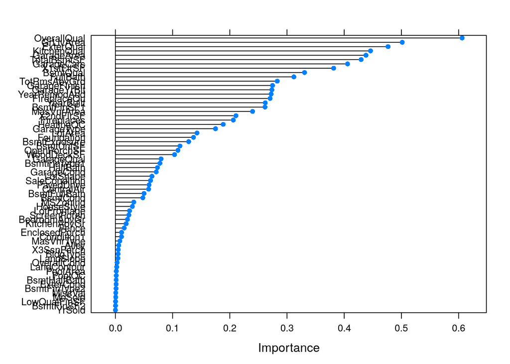

```r
plot(rankedImportance)
```

```r
# Set the importance threshold and calculate the list of attributes that don't contribute to the importance threshold
maxThreshold <- 0.99
rankedAttributes <- rankedImportance$importance
rankedAttributes <- rankedAttributes[order(-rankedAttributes$Overall),,drop=FALSE]
totalWeight <- sum(rankedAttributes)
i <- 1
accumWeight <- 0
exit_now <- FALSE
while ((i <= totAttr) & !exit_now) {
  accumWeight = accumWeight + rankedAttributes[i,]
  if ((accumWeight/totalWeight) >= maxThreshold) {
    exit_now <- TRUE
  } else {
    i <- i + 1
  }
}
lowImportance <- rankedAttributes[(i+1):(totAttr),,drop=FALSE]
lowAttributes <- rownames(lowImportance)
cat('Number of attributes contributed to the importance threshold:',i,"\n")
```

```
## Number of attributes contributed to the importance threshold: 44
```

```r
cat('Number of attributes found to be of low importance:',length(lowAttributes))
```

```
## Number of attributes found to be of low importance: 20
```

```r
# Removing the unselected attributes from the training and validation dataframes
xy_train <- xy_train[, !(names(xy_train) %in% lowAttributes)]
xy_test <- xy_test[, !(names(xy_test) %in% lowAttributes)]
```

### 3.c) Data Transforms

```r
# Not applicable for this iteration of the project.
```

### 3.d) Display the Final Dataset for Model-Building

```r
dim(xy_train)
```

```
## [1] 1021   45
```

```r
dim(xy_test)
```

```
## [1] 435  45
```

```r
sapply(xy_train, class)
```

```
##      MSZoning   LotFrontage       LotArea      LotShape    HouseStyle
##      "factor"      "impute"     "integer"      "factor"      "factor"
##   OverallQual     YearBuilt  YearRemodAdd    MasVnrArea     ExterQual
##     "integer"     "integer"     "integer"      "impute"     "numeric"
##    Foundation      BsmtQual      BsmtCond  BsmtExposure  BsmtFinType1
##      "factor"     "numeric"     "numeric"     "numeric"     "numeric"
##    BsmtFinSF1     BsmtUnfSF   TotalBsmtSF     HeatingQC    CentralAir
##     "integer"     "integer"     "integer"     "numeric"      "factor"
##     X1stFlrSF     X2ndFlrSF     GrLivArea  BsmtFullBath      FullBath
##     "integer"     "integer"     "integer"     "integer"     "integer"
##      HalfBath  BedroomAbvGr  KitchenAbvGr   KitchenQual  TotRmsAbvGrd
##     "integer"     "integer"     "integer"     "numeric"     "integer"
##    Fireplaces   FireplaceQu    GarageType   GarageYrBlt  GarageFinish
##     "integer"     "numeric"      "factor"      "impute"     "numeric"
##    GarageCars    GarageArea    GarageQual    GarageCond    PavedDrive
##     "integer"     "integer"     "numeric"     "numeric"      "factor"
##    WoodDeckSF   OpenPorchSF   ScreenPorch SaleCondition     targetVar
##     "integer"     "integer"     "integer"      "factor"     "integer"
```

```r
if (notifyStatus) email_notify(paste("Data Cleaning and Transformation completed!",date()))
proc.time()-startTimeScript
```

```
##    user  system elapsed
##  13.261   7.417  13.062
```

## 4. Model and Evaluate Algorithms

After the data-prep, we next work on finding a workable model by evaluating a subset of machine learning algorithms that are good at exploiting the structure of the dataset. The typical evaluation tasks include:

- Defining test options such as cross validation and the evaluation metric to use.
- Spot checking a suite of linear and nonlinear machine learning algorithms.
- Comparing the estimated accuracy of algorithms.

For this project, we will evaluate four linear, one non-linear, and three ensemble algorithms:

Linear Algorithm: Linear Regression, Ridge, The Lasso, Elasticnet

Non-Linear Algorithm: Decision Trees (CART)

Ensemble Algorithms: Bagged CART, Random Forest, and Gradient Boosting

The random number seed is reset before each run to ensure that the evaluation of each algorithm is performed using the same data splits. It ensures the results are directly comparable.

### 4.a) Generate models using linear algorithms

```r
# Linear Regression (Regression)
if (notifyStatus) email_notify(paste("Linear Regression modeling has begun!",date()))
startTimeModule <- proc.time()
set.seed(seedNum)
fit.lm <- train(targetVar~., data=xy_train, method="lm", metric=metricTarget, trControl=control)
print(fit.lm)
```

```
## Linear Regression
##
## 1021 samples
##   44 predictor
##
## No pre-processing
## Resampling: Cross-Validated (10 fold, repeated 3 times)
## Summary of sample sizes: 920, 920, 918, 918, 917, 921, ...
## Resampling results:
##
##   RMSE     Rsquared  MAE
##   27723.9  0.870432  20064.35
##
## Tuning parameter 'intercept' was held constant at a value of TRUE
```

```r
proc.time()-startTimeModule
```

```
##    user  system elapsed
##   1.367   0.000   1.370
```

```r
if (notifyStatus) email_notify(paste("Linear Regression modeling completed!",date()))
```

```r
# Ridge (Regression)
if (notifyStatus) email_notify(paste("Ridge Regression modeling has begun!",date()))
startTimeModule <- proc.time()
set.seed(seedNum)
fit.ridge <- train(targetVar~., data=xy_train, method="ridge", metric=metricTarget, trControl=control)
print(fit.ridge)
```

```
## Ridge Regression
##
## 1021 samples
##   44 predictor
##
## No pre-processing
## Resampling: Cross-Validated (10 fold, repeated 3 times)
## Summary of sample sizes: 920, 920, 918, 918, 917, 921, ...
## Resampling results across tuning parameters:
##
##   lambda  RMSE      Rsquared  MAE
##   0e+00   27723.90  0.870432  20064.35
##   1e-04   27716.89  0.870497  20059.70
##   1e-01   28257.21  0.873137  21131.32
##
## RMSE was used to select the optimal model using the smallest value.
## The final value used for the model was lambda = 1e-04.
```

```r
proc.time()-startTimeModule
```

```
##    user  system elapsed
##  10.956   7.237   9.540
```

```r
if (notifyStatus) email_notify(paste("Ridge Regression modeling completed!",date()))
```

```r
# The Lasso (Regression)
if (notifyStatus) email_notify(paste("The Lasso modeling has begun!",date()))
startTimeModule <- proc.time()
set.seed(seedNum)
fit.lasso <- train(targetVar~., data=xy_train, method="lasso", metric=metricTarget, trControl=control)
print(fit.lasso)
```

```
## The lasso
##
## 1021 samples
##   44 predictor
##
## No pre-processing
## Resampling: Cross-Validated (10 fold, repeated 3 times)
## Summary of sample sizes: 920, 920, 918, 918, 917, 921, ...
## Resampling results across tuning parameters:
##
##   fraction  RMSE      Rsquared   MAE
##   0.1       57032.05  0.7023422  39986.83
##   0.5       27673.25  0.8706497  19441.89
##   0.9       27613.78  0.8713983  19957.32
##
## RMSE was used to select the optimal model using the smallest value.
## The final value used for the model was fraction = 0.9.
```

```r
proc.time()-startTimeModule
```

```
##    user  system elapsed
##   4.624   2.879   4.086
```

```r
if (notifyStatus) email_notify(paste("The Lasso modeling completed!",date()))
```

```r
# Elasticnet (Regression)
if (notifyStatus) email_notify(paste("Elasticnet modeling has begun!",date()))
startTimeModule <- proc.time()
set.seed(seedNum)
fit.enet <- train(targetVar~., data=xy_train, method="enet", metric=metricTarget, trControl=control)
print(fit.enet)
```

```
## Elasticnet
##
## 1021 samples
##   44 predictor
##
## No pre-processing
## Resampling: Cross-Validated (10 fold, repeated 3 times)
## Summary of sample sizes: 920, 920, 918, 918, 917, 921, ...
## Resampling results across tuning parameters:
##
##   lambda  fraction  RMSE      Rsquared   MAE
##   0e+00   0.050     65624.17  0.6275320  47451.26
##   0e+00   0.525     27545.15  0.8717431  19432.25
##   0e+00   1.000     27723.90  0.8704320  20064.35
##   1e-04   0.050     65673.92  0.6267939  47493.39
##   1e-04   0.525     27558.95  0.8716435  19433.05
##   1e-04   1.000     27716.89  0.8704970  20059.70
##   1e-01   0.050     67859.57  0.6143864  49378.92
##   1e-01   0.525     29103.08  0.8573852  20295.62
##   1e-01   1.000     28257.21  0.8731370  21131.32
##
## RMSE was used to select the optimal model using the smallest value.
## The final values used for the model were fraction = 0.525 and lambda = 0.
```

```r
proc.time()-startTimeModule
```

```
##    user  system elapsed
##  11.744   7.699  10.251
```

```r
if (notifyStatus) email_notify(paste("Elasticnet modeling completed!",date()))
```

### 4.b) Generate models using nonlinear algorithms

```r
# Decision Tree - CART (Regression/Classification)
if (notifyStatus) email_notify(paste("Decision Tree modeling has begun!",date()))
startTimeModule <- proc.time()
set.seed(seedNum)
fit.cart <- train(targetVar~., data=xy_train, method="rpart", metric=metricTarget, trControl=control)
print(fit.cart)
```

```
## CART
##
## 1021 samples
##   44 predictor
##
## No pre-processing
## Resampling: Cross-Validated (10 fold, repeated 3 times)
## Summary of sample sizes: 920, 920, 918, 918, 917, 921, ...
## Resampling results across tuning parameters:
##
##   cp          RMSE      Rsquared   MAE
##   0.05522039  50669.40  0.5593333  36463.58
##   0.13867577  57088.27  0.4395478  40938.55
##   0.43402587  63831.91  0.3960284  46480.26
##
## RMSE was used to select the optimal model using the smallest value.
## The final value used for the model was cp = 0.05522039.
```

```r
proc.time()-startTimeModule
```

```
##    user  system elapsed
##   2.520   1.397   2.253
```

```r
if (notifyStatus) email_notify(paste("Decision Tree modeling completed!",date()))
```

### 4.c) Generate models using ensemble algorithms

In this section, we will explore the use and tuning of ensemble algorithms to see whether we can improve the results.

```r
# Bagged CART (Regression/Classification)
if (notifyStatus) email_notify(paste("Bagged CART modeling has begun!",date()))
startTimeModule <- proc.time()
set.seed(seedNum)
fit.bagcart <- train(targetVar~., data=xy_train, method="treebag", metric=metricTarget, trControl=control)
print(fit.bagcart)
```

```
## Bagged CART
##
## 1021 samples
##   44 predictor
##
## No pre-processing
## Resampling: Cross-Validated (10 fold, repeated 3 times)
## Summary of sample sizes: 920, 920, 918, 918, 917, 921, ...
## Resampling results:
##
##   RMSE      Rsquared   MAE
##   33337.23  0.8176343  23253.75
```

```r
proc.time()-startTimeModule
```

```
##    user  system elapsed
##  25.006  15.944  22.016
```

```r
if (notifyStatus) email_notify(paste("Bagged CART modeling completed!",date()))
```

```r
# Random Forest (Regression/Classification)
if (notifyStatus) email_notify(paste("Random Forest modeling has begun!",date()))
startTimeModule <- proc.time()
set.seed(seedNum)
fit.rf <- train(targetVar~., data=xy_train, method="rf", metric=metricTarget, trControl=control)
print(fit.rf)
```

```
## Random Forest
##
## 1021 samples
##   44 predictor
##
## No pre-processing
## Resampling: Cross-Validated (10 fold, repeated 3 times)
## Summary of sample sizes: 920, 920, 918, 918, 917, 921, ...
## Resampling results across tuning parameters:
##
##   mtry  RMSE      Rsquared   MAE
##    2    31923.07  0.8695620  20314.58
##   35    25644.20  0.8939916  16763.06
##   69    26532.11  0.8841837  17386.44
##
## RMSE was used to select the optimal model using the smallest value.
## The final value used for the model was mtry = 35.
```

```r
proc.time()-startTimeModule
```

```
##    user  system elapsed
## 546.489   0.584 548.423
```

```r
if (notifyStatus) email_notify(paste("Random Forest modeling completed!",date()))
```

```r
# Gradient Boosting (Regression/Classification)
if (notifyStatus) email_notify(paste("Gradient Boosting modeling has begun!",date()))
startTimeModule <- proc.time()
set.seed(seedNum)
# fit.gbm <- train(targetVar~., data=xy_train, method="xgbTree", metric=metricTarget, trControl=control, verbose=F)
fit.gbm <- train(targetVar~., data=xy_train, method="gbm", metric=metricTarget, trControl=control, verbose=F)
print(fit.gbm)
```

```
## Stochastic Gradient Boosting
##
## 1021 samples
##   44 predictor
##
## No pre-processing
## Resampling: Cross-Validated (10 fold, repeated 3 times)
## Summary of sample sizes: 920, 920, 918, 918, 917, 921, ...
## Resampling results across tuning parameters:
##
##   interaction.depth  n.trees  RMSE      Rsquared   MAE
##   1                   50      32256.44  0.8394635  22190.67
##   1                  100      27351.05  0.8729550  19061.63
##   1                  150      26328.30  0.8821025  18272.81
##   2                   50      27469.59  0.8752646  18968.91
##   2                  100      25040.39  0.8929521  17293.32
##   2                  150      24619.07  0.8961084  16963.44
##   3                   50      25860.52  0.8867854  17773.16
##   3                  100      24449.01  0.8972931  16715.17
##   3                  150      24204.17  0.8992738  16560.66
##
## Tuning parameter 'shrinkage' was held constant at a value of 0.1
##
## Tuning parameter 'n.minobsinnode' was held constant at a value of 10
## RMSE was used to select the optimal model using the smallest value.
## The final values used for the model were n.trees = 150,
##  interaction.depth = 3, shrinkage = 0.1 and n.minobsinnode = 10.
```

```r
proc.time()-startTimeModule
```

```
##    user  system elapsed
##  24.495   0.000  24.547
```

```r
if (notifyStatus) email_notify(paste("Gradient Boosting modeling completed!",date()))
```

### 4.d) Compare baseline algorithms

```r
results <- resamples(list(LR=fit.lm, RIDGE=fit.ridge, LASSO=fit.lasso, ENET=fit.enet, CART=fit.cart, BagCART=fit.bagcart, RF=fit.rf, GBM=fit.gbm))
summary(results)
```

```
##
## Call:
## summary.resamples(object = results)
##
## Models: LR, RIDGE, LASSO, ENET, CART, BagCART, RF, GBM
## Number of resamples: 30
##
## MAE
##             Min.  1st Qu.   Median     Mean  3rd Qu.     Max. NA's
## LR      17164.61 18828.09 19494.39 20064.35 21019.50 24252.78    0
## RIDGE   17153.04 18827.73 19487.09 20059.70 21014.53 24238.42    0
## LASSO   17101.91 18733.63 19397.18 19957.32 20957.56 24006.80    0
## ENET    16893.59 18117.70 18994.88 19432.25 20472.82 23335.98    0
## CART    32452.96 34684.83 35964.42 36463.58 37889.10 41776.50    0
## BagCART 20139.43 22098.41 23322.00 23253.75 23917.01 26041.88    0
## RF      13691.51 15392.76 16770.91 16763.06 18017.82 19915.60    0
## GBM     13218.99 15608.96 16550.63 16560.66 17552.46 19431.01    0
##
## RMSE
##             Min.  1st Qu.   Median     Mean  3rd Qu.     Max. NA's
## LR      23045.40 24882.74 26934.32 27723.90 28822.67 37539.33    0
## RIDGE   23024.71 24882.10 26912.52 27716.89 28808.01 37531.06    0
## LASSO   22977.45 24792.75 26719.53 27613.78 28681.54 37424.27    0
## ENET    23086.35 24557.86 26154.08 27545.15 28957.37 38639.37    0
## CART    40687.63 46345.04 50784.17 50669.40 53379.77 64551.80    0
## BagCART 27189.73 30549.89 32375.11 33337.23 35334.05 42015.50    0
## RF      20514.98 23021.85 24300.27 25644.20 26636.01 34642.58    0
## GBM     18729.71 22015.38 23747.68 24204.17 26393.19 30529.72    0
##
## Rsquared
##              Min.   1st Qu.    Median      Mean   3rd Qu.      Max. NA's
## LR      0.8171110 0.8575847 0.8712952 0.8704320 0.8811253 0.9090316    0
## RIDGE   0.8172139 0.8576305 0.8713218 0.8704970 0.8811573 0.9091944    0
## LASSO   0.8186464 0.8593825 0.8730503 0.8713983 0.8819839 0.9095826    0
## ENET    0.8110135 0.8605097 0.8724889 0.8717431 0.8820323 0.9069853    0
## CART    0.4617368 0.5167291 0.5614495 0.5593333 0.6067084 0.6607469    0
## BagCART 0.7688752 0.8020928 0.8161055 0.8176343 0.8355543 0.8811287    0
## RF      0.8241752 0.8863459 0.8963179 0.8939916 0.9061288 0.9275739    0
## GBM     0.8487672 0.8835777 0.9002088 0.8992738 0.9146372 0.9406470    0
```

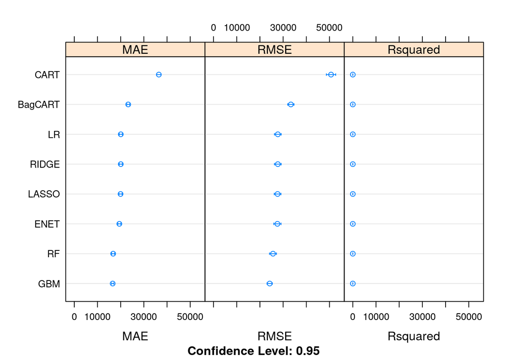

```r
dotplot(results)
```

```r
cat('The average RMSE from all models is:',
    mean(c(results$values$`LR~RMSE`,results$values$`RIDGE~RMSE`,results$values$`LASSO~RMSE`,results$values$`ENET~RMSE`,results$values$`CART~RMSE`,results$values$`BagCART~RMSE`,results$values$`RF~RMSE`,results$values$`GBM~RMSE`)))
```

```
## The average RMSE from all models is: 30556.84
```

## 5. Improve Accuracy or Results

After we achieve a short list of machine learning algorithms with good level of accuracy, we can leverage ways to improve the accuracy of the models.

### 5.a) Algorithm Tuning

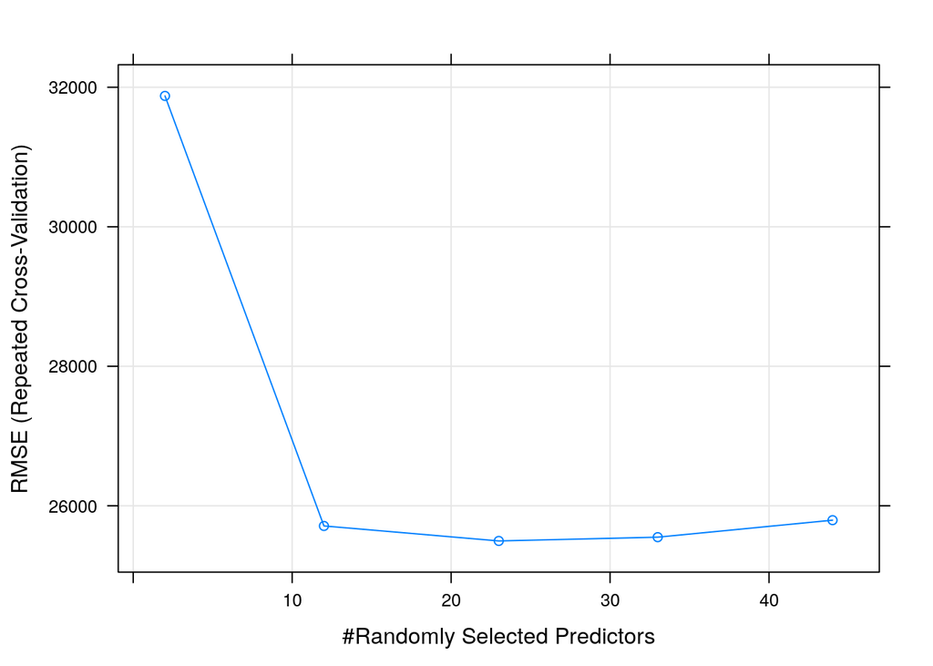

```r
# Tuning algorithm #1 - Random Forest
if (notifyStatus) email_notify(paste("Algorithm #1 tuning has begun!",date()))
startTimeModule <- proc.time()
set.seed(seedNum)
grid <- expand.grid(mtry = c(2,12,23,33,44))
fit.final1 <- train(targetVar~., data=xy_train, method="rf", metric=metricTarget, tuneGrid=grid, trControl=control)
plot(fit.final1)
```

```r
print(fit.final1)
```

```
## Random Forest
##
## 1021 samples
##   44 predictor
##
## No pre-processing
## Resampling: Cross-Validated (10 fold, repeated 3 times)
## Summary of sample sizes: 920, 920, 918, 918, 917, 921, ...
## Resampling results across tuning parameters:
##
##   mtry  RMSE      Rsquared   MAE
##    2    31875.53  0.8696855  20244.81
##   12    25710.72  0.8969189  16664.62
##   23    25495.77  0.8966511  16659.31
##   33    25549.89  0.8947737  16768.07
##   44    25793.56  0.8920841  16890.81
##
## RMSE was used to select the optimal model using the smallest value.
## The final value used for the model was mtry = 23.
```

```r
proc.time()-startTimeModule
```

```
##    user  system elapsed
## 646.500   1.112 649.051
```

```r
if (notifyStatus) email_notify(paste("Algorithm #1 tuning completed!",date()))
```

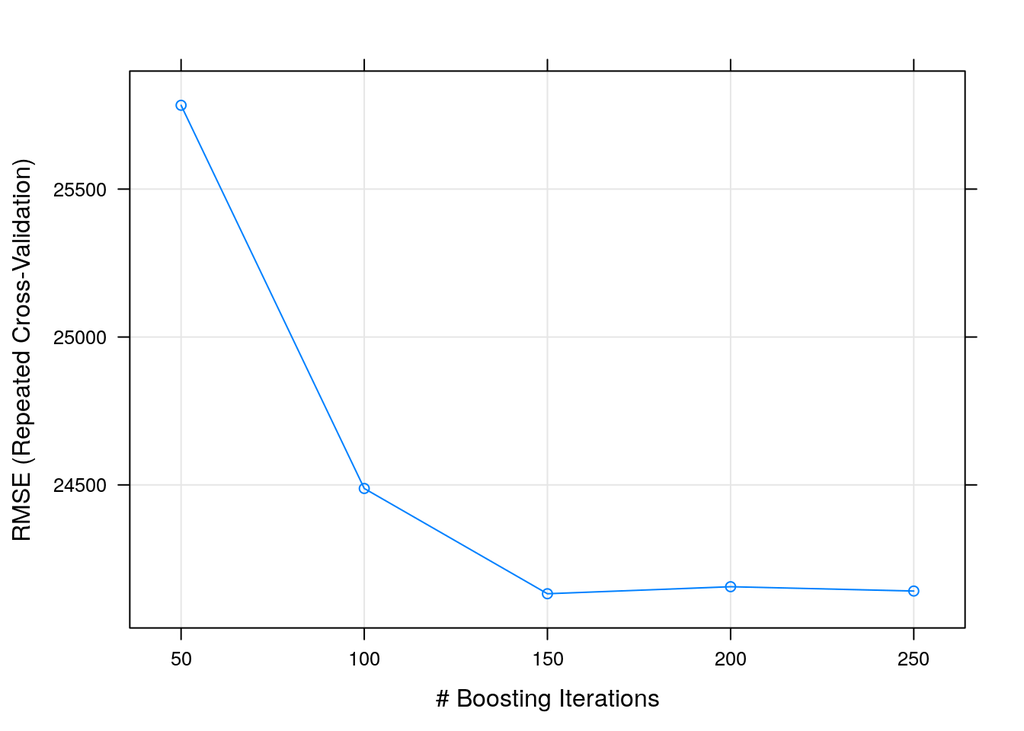

```r
# Tuning algorithm #2 - Gradient Boosting
if (notifyStatus) email_notify(paste("Algorithm #2 tuning has begun!",date()))
startTimeModule <- proc.time()
set.seed(seedNum)
grid <- expand.grid(n.trees = c(50,100,150,200,250), interaction.depth = 3, shrinkage = 0.1, n.minobsinnode = 10)
fit.final2 <- train(targetVar~., data=xy_train, method="gbm", metric=metricTarget, tuneGrid=grid, trControl=control, verbose=F)
plot(fit.final2)
```

```r
print(fit.final2)
```

```
## Stochastic Gradient Boosting
##
## 1021 samples
##   44 predictor
##
## No pre-processing
## Resampling: Cross-Validated (10 fold, repeated 3 times)
## Summary of sample sizes: 920, 920, 918, 918, 917, 921, ...
## Resampling results across tuning parameters:
##
##   n.trees  RMSE      Rsquared   MAE
##    50      25783.30  0.8878059  17618.97
##   100      24488.00  0.8973132  16718.92
##   150      24132.16  0.9002457  16489.41
##   200      24155.91  0.9001027  16459.21
##   250      24141.29  0.9004553  16467.73
##
## Tuning parameter 'interaction.depth' was held constant at a value of
##  3
## Tuning parameter 'shrinkage' was held constant at a value of 0.1
##
## Tuning parameter 'n.minobsinnode' was held constant at a value of 10
## RMSE was used to select the optimal model using the smallest value.
## The final values used for the model were n.trees = 150,
##  interaction.depth = 3, shrinkage = 0.1 and n.minobsinnode = 10.
```

```r
proc.time()-startTimeModule
```

```
##    user  system elapsed
##  18.837   0.006  18.882
```

```r
if (notifyStatus) email_notify(paste("Algorithm #2 tuning completed!",date()))
```

### 5.d) Compare Algorithms After Tuning

```r
results <- resamples(list(RF=fit.final1, GBM=fit.final2))
summary(results)
```

```
##
## Call:
## summary.resamples(object = results)
##
## Models: RF, GBM
## Number of resamples: 30
##
## MAE
##         Min.  1st Qu.   Median     Mean  3rd Qu.     Max. NA's
## RF  13681.49 15291.43 16757.04 16659.31 17968.29 19829.06    0
## GBM 13995.40 15442.74 16287.94 16489.41 17218.23 19607.96    0
##
## RMSE
##         Min.  1st Qu.   Median     Mean  3rd Qu.     Max. NA's
## RF  20721.26 22547.79 23695.61 25495.77 27268.98 35126.16    0
## GBM 19370.69 21652.47 23171.77 24132.16 26684.83 30930.55    0
##
## Rsquared
##          Min.   1st Qu.    Median      Mean   3rd Qu.      Max. NA's
## RF  0.8280076 0.8849752 0.9013201 0.8966511 0.9100051 0.9280492    0
## GBM 0.8504310 0.8877089 0.8975555 0.9002457 0.9159478 0.9390407    0
```

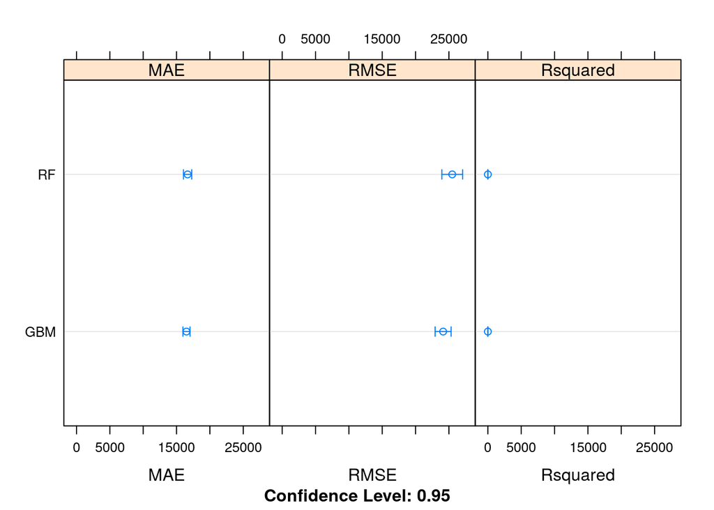

```r
dotplot(results)
```

## 6. Finalize Model and Present Results

Once we have narrow down to a model that we believe can make accurate predictions on unseen data, we are ready to finalize it. Finalizing a model may involve sub-tasks such as:

- Using an optimal model tuned to make predictions on unseen data.
- Creating a standalone model using the tuned parameters
- Saving an optimal model to file for later use.

```r
if (notifyStatus) email_notify(paste("Model Validation and Final Model Creation has begun!",date()))
```

### 6.a) Predictions on validation dataset

```r
predictions <- predict(fit.final1, newdata=xy_test)
print(RMSE(predictions, y_test))
```

```
## [1] 24753.62
```

```r
print(R2(predictions, y_test))
```

```
## [1] 0.907829
```

```r
predictions <- predict(fit.final2, newdata=xy_test)
print(RMSE(predictions, y_test))
```

```
## [1] 23918.59
```

```r
print(R2(predictions, y_test))
```

```
## [1] 0.9096486
```

### 6.b) Create standalone model on entire training dataset

```r
startTimeModule <- proc.time()
library(gbm)
set.seed(seedNum)

# Combining the training and test datasets to form the original dataset that will be used for training the final model
xy_complete <- rbind(xy_train, xy_test)

# finalModel <- gbm(targetVar~., xy_complete, n.trees = 150, interaction.depth = 3, shrinkage = 0.1, n.minobsinnode = 10, verbose = FALSE)
# summary(finalModel)
proc.time()-startTimeModule
```

```
##    user  system elapsed
##   0.017   0.000   0.018
```

### 6.c) Save model for later use

```r
#saveRDS(finalModel, "./finalModel_Regression.rds")
```

```r
if (notifyStatus) email_notify(paste("Model Validation and Final Model Creation Completed!",date()))
proc.time()-startTimeScript
```

```
##     user   system  elapsed
## 1307.210   44.338 1304.886
```